# Homework week 10 day 2

```r
library(tidyverse)
library(janitor)
library(GGally)
library(fastDummies)
```

## 1. Load the diamonds.csv data set and undertake an initial exploration of the data. You will find a description of the meanings of the variables on the relevant Kaggle page: https://www.kaggle.com/shivam2503/diamonds/

```r
diamonds <- read_csv("diamonds.csv")
```

## 2. We expect the carat of the diamonds to be strong correlated with the physical dimensions x, y and z. Use ggpairs() to investigate correlations between these four variables.

Very strong correlation - carat is a measure of diamond weight

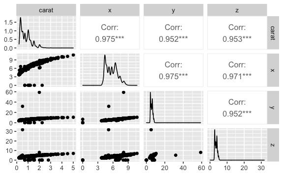

```r
diamonds_carat_dims <- diamonds %>%
select(carat, x, y, z)

ggpairs(diamonds_carat_dims)
```

## 3. So, we do find significant correlations. Let’s drop columns x, y and z from the dataset, in preparation to use only carat going forward.

```r
diamonds %>%
  distinct(color) %>%
  arrange(color)
```

| color |
| --- |
| D |
| E |
| F |
| G |
| H |
| I |
| J |

### Add numeric versions of “quality” columns

lowest number = lowest “quality”

Data dictionary:

- **cut:** quality of the cut (Fair, Good, Very Good, Premium, Ideal)
- **color:** diamond colour, from J (worst) to D (best)
- **clarity:** a measurement of how clear the diamond is (I1 (worst), SI2, SI1, VS2, VS1, VVS2, VVS1, IF (best))

```r
diamonds_trim <- diamonds %>%
  # add numeric cut quality column
  mutate(cut_numeric = recode(cut, "Fair" = 1,
                                   "Good" = 2,
                                   "Very Good" = 3,
                                   "Premium" = 4,
                                   "Ideal" = 5)) %>%
  # add numeric clarity quality column
  mutate(clarity_numeric = recode(clarity, "I1" = 1,
                                   "SI2" = 2,
                                   "SI1" = 3,
                                   "VS2" = 4,
                                   "VS1" = 5,
                                   "VVS2" = 6,
                                   "VVS1" = 7,
                                   "IF" = 8,
                                  )) %>%
  # add numeric colour quality column
  mutate(color_numeric = recode(color, "J" = 1,
                                   "I" = 2,
                                   "H" = 3,
                                   "G" = 4,
                                   "F" = 5,
                                   "E" = 6,
                                   "D" = 7,
                                  )) %>%
  select(-c(X1, x, y, z, cut, color, clarity))
```

# We are interested in developing a regression model for the price of a diamond in terms of the possible predictor variables in the dataset:

## 4 i. Use ggpairs() to investigate correlations between price and the predictors (this may take a while to run, don’t worry, make coffee or something).

Carat has a strong correlation with price

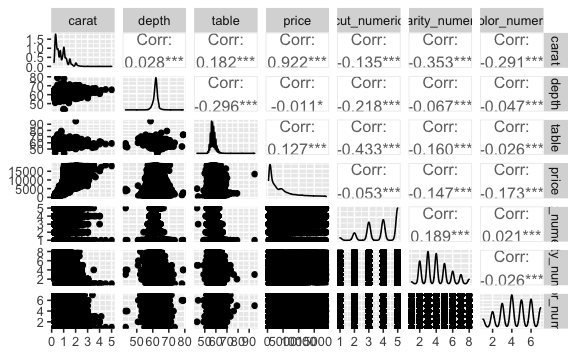

```r
ggpairs(diamonds_trim)
```

## 4ii. Perform further ggplot visualisations of any significant correlations you find.

Lots of them seem to tie up exactly with the 1, 2 & 3 carat lines - wonder if deliberately cut to be of a size which gets the best price?

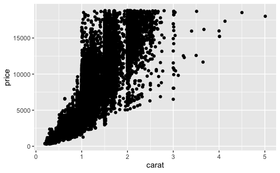

```r
diamonds_trim %>%
  ggplot(aes(x = carat, y = price))+
  geom_point()
```

# Shortly we may try a regression fit using one or more of the categorical predictors cut, clarity and color, so let’s investigate these predictors:

Guess this means my recoding of these columns above is wrong!

## 5 i. Investigate the factor levels of these predictors. How many dummy variables do you expect for each of them?

These are the original numbers of predictors: cut: 5 color: 7 clarity: 8

Because one from each group can be derived from the others in the same group, the total number of dummy variables would be 17

## 5 ii. Use the dummy_cols() function in the fastDummies package to generate dummies for these predictors and check the number of dummies in each case.

```r
diamonds_dummy_cols <- diamonds %>%
dummy_cols()
names(diamonds_dummy_cols)
```

```
 [1] "X1"            "carat"         "cut"           "color"
 [5] "clarity"       "depth"         "table"         "price"
 [9] "x"             "y"             "z"             "cut_Fair"
[13] "cut_Good"      "cut_Ideal"     "cut_Premium"   "cut_Very Good"
[17] "color_D"       "color_E"       "color_F"       "color_G"
[21] "color_H"       "color_I"       "color_J"       "clarity_I1"
[25] "clarity_IF"    "clarity_SI1"   "clarity_SI2"   "clarity_VS1"
[29] "clarity_VS2"   "clarity_VVS1"  "clarity_VVS2"
```